# Final Project

Author

Will Adams

## Predictive Factors of Player Market Value in World Football

## 1. Introduction

The business model of professional European football has reached a point of reckoning. The hypercompetitive open-league system with no salary cap has resulted in an environment where profit generation is not a realistic option. Rather, the increased financialization of European football has seen clubs continue to overspend their abilities in a race-to-the-bottom for talent. This has resulted in the exponential growth of player spending, which reached more than £6.5bn in the summer 2023 transfer window.

This study aims to better understand what factors influence market value in players to help clubs move towards more sustainable transfer models. By analyzing what factors contribute towards player market value, clubs can be more prudent in their player trading and academy development philosophies. The project investigates whether factors such as nationality, age, and position are related to player market value.

To address this question, I used a data set from Kaggle that scraped information on global soccer players from Transfermarkt and fbref.com. The data was last updated on September 2nd, 2021. Each case in the data set is a different player. Here is a snapshot of 5 randomly chosen rows of the data set being used:

```
# A tibble: 5 × 9
  Player             Club     Age Position Nation  Value League `Gls/90 (20/21)`
  <chr>              <chr>  <dbl> <chr>    <chr>   <dbl> <chr>             <dbl>
1 Alvaro Odriozola   ACF F…    25 Defender Spain  9   e6 Serie…             0.22
2 Morgan Gibbs-White Sheff…    21 midfield Engla… 6.30e6 Premi…             0.22
3 Lukas Hradecky     Bayer…    31 Goalkee… Finla… 5.40e6 Bunde…             0
4 Alexander Djiku    RC St…    27 Defender Ghana  5.85e6 Ligue…             0
5 Martinelli         Arsen…    20 attack   Brazil 1.98e7 Premi…             0.31
# ℹ 1 more variable: `Touches (20/21)` <dbl>
```

## 2. Exploratory data analysis

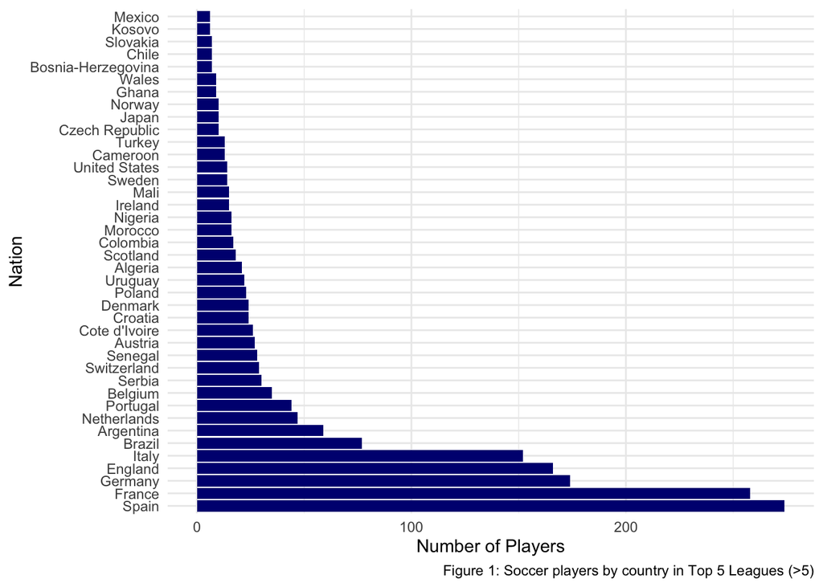

The original sample was 2,075 players. I filtered the dataset to include certain categories that I thought it would be interesting to analyze. Since some of the players had missing values for the factors selected, I dropped these rows from consideration. I am not sure why these values were missing, so cannot comment on the impact dropping these results might have on my results.

After cleaning the data, my total sample size was 1,910 players. Looking at the distribution of player values, it was positively skewed and thus I applied a logarithmic transformation. There was also a potential outlier at 150 million, which will be something important to consider throughout our analysis.

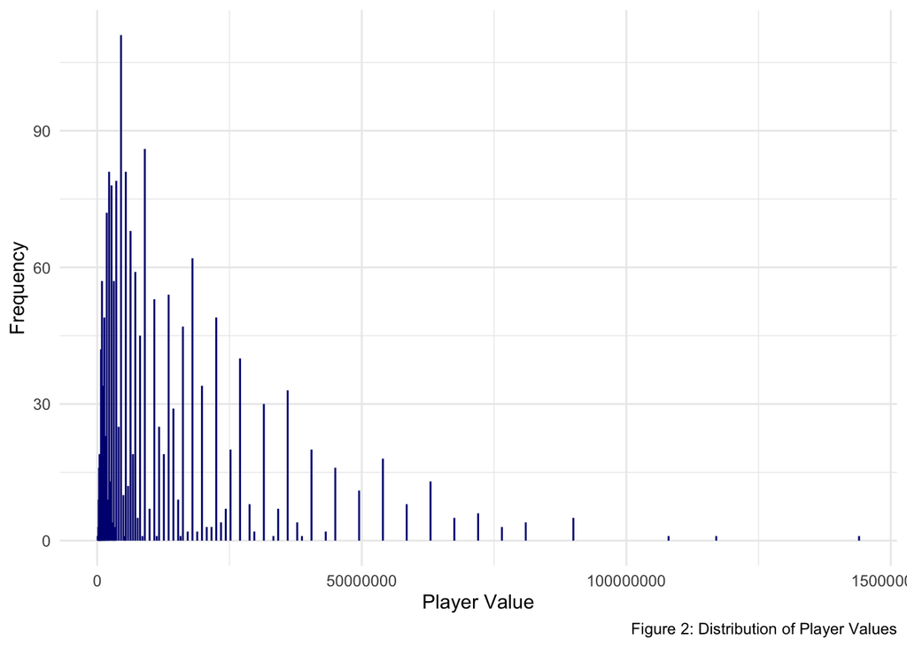

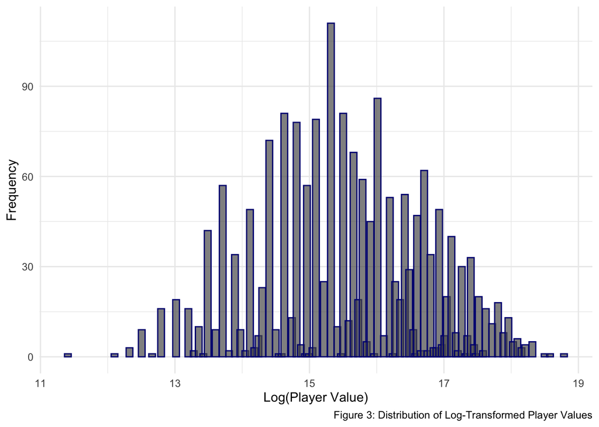

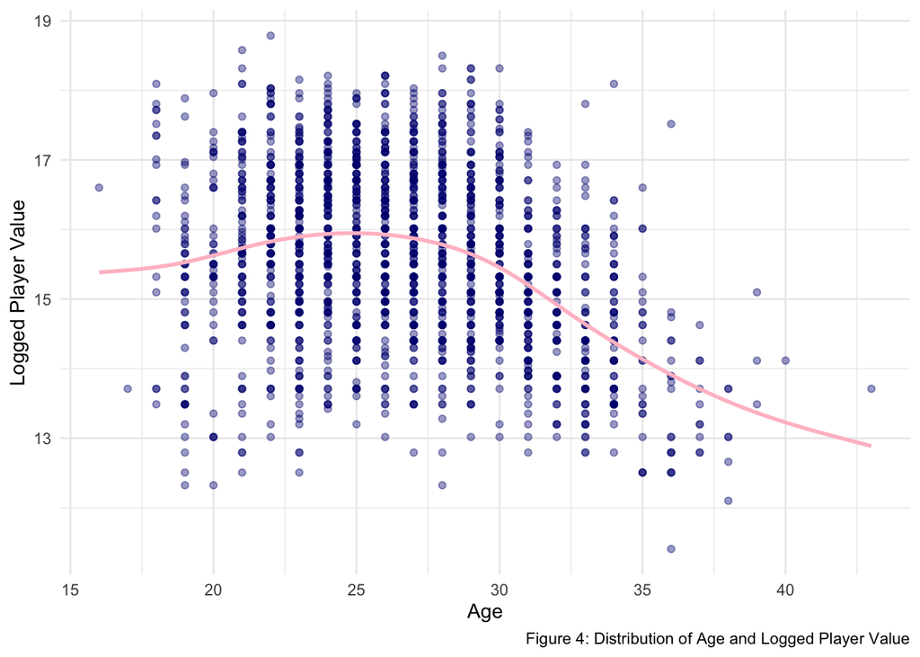

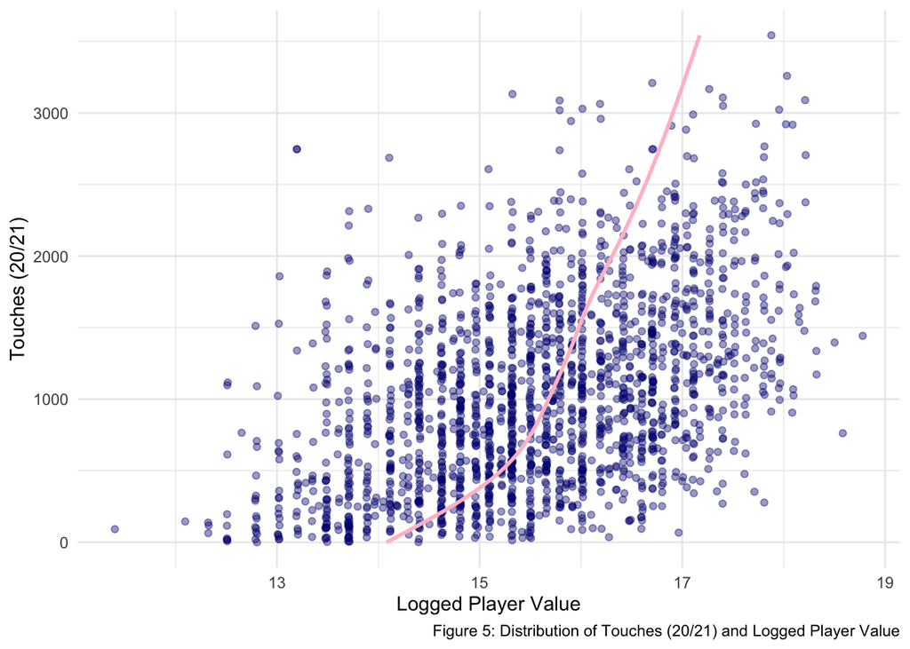

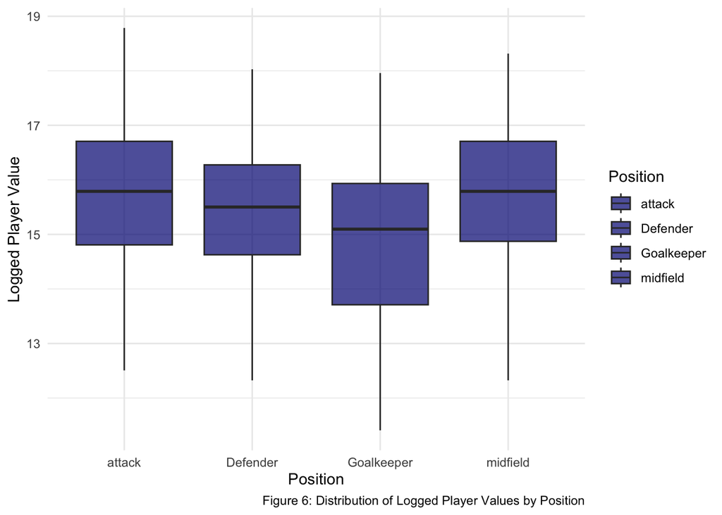

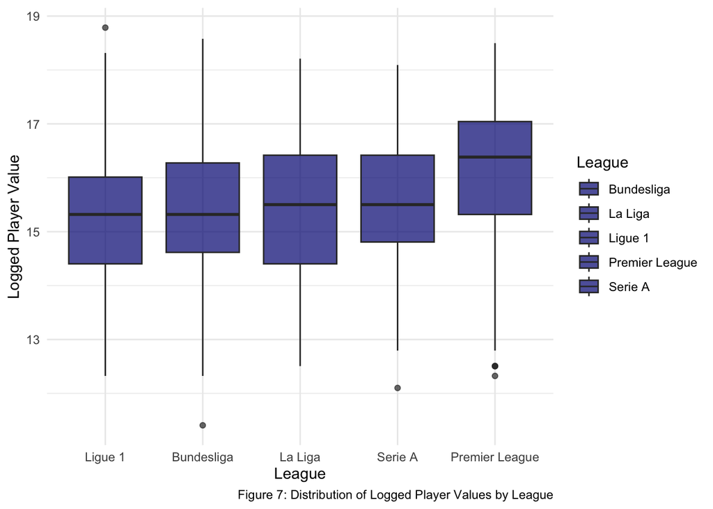

## 4. Discussion

### 4.1 Conclusions

### 4.2 Limitations

### 4.3 Further Questions

## 5. Citations and References